# Dades de creixement (Francesc González)

Mercè Farré

17/7/2020

```r
library(car)
library(readxl)
library(dagitty)
library(lavaan)
```

## Dades

Correcció d’algunes dades anòmales, blocs de pes a 20 dies creació dels dataframes de mascles i femelles, …

```r
dadesFr <- read_excel("AGL2016-75463_BW.xlsx",sheet = "TOT")

dim(dadesFr)
```

```
## [1] 729  12
```

```r
 # 729 ,12
names(dadesFr)
```

```
##  [1] "sow"   "treat" "band"  "pig"   "sex"   "block" "bw0"   "bw20"  "bw33"
## [10] "bw60"  "bw120" "bw163"
```

```r
subset(dadesFr,bw163<65)
```

```
## # A tibble: 2 x 12
##     sow treat  band   pig sex   block   bw0  bw20  bw33  bw60 bw120 bw163
##   <dbl> <dbl> <dbl> <dbl> <chr> <dbl> <dbl> <dbl> <dbl> <dbl> <dbl> <dbl>
## 1  7076     1     1   390 f         1 0.883  5.29  6.07  11.6  56    56
## 2  9021     3     1   134 m         1 1.18   3.77  4.00  10.7  40.0  53.4
```

```r
dim(subset(dadesFr,bw163<65|is.na(bw163))) # 35 casos (3+32)
```

```
## [1] 35 12
```

```r
## traiem dos casos que no arriben als 65kg a d163
dadesFr <- subset(dadesFr,bw163 >= 65 & !is.na(bw163))
dim(dadesFr) # 729-35=694 casos
```

```
## [1] 694  12
```

```r
### ADG 0-20 : lactació

adgLac <- (dadesFr$bw20 - dadesFr$bw0)/20
dadesFr$adgLac <- adgLac

## redefineixo block, a partir dels tercils de pes al final de la lactació
x <- dadesFr$bw20
block <- cut(x,breaks=quantile(x,seq(0,1,1/3)),labels=1:3,include.lowest=T)
dadesFr$block <- block

# subsets mascles i femelles

dadesFrM <- subset(dadesFr,sex=="m") # males
dadesFrF <- subset(dadesFr,sex=="f") # females
```

```r
# NOT RUN  eval=F no s'avalua
## variable sexe*bloc i sexe*tractament
#sexByBlock <- paste0(dadesFr$sex,dadesFr$block)
#dadesFr <- data.frame(dadesFr[1:6],sexByBlock,dadesFr[7:13])

#sexByTreat <- paste0(dadesFr$sex,dadesFr$treat)
#dadesFr <- data.frame(dadesFr[1:7],sexByTreat,dadesFr[8:14])
```

## Funció per definir intervals de coonfiança pels coeficients i pels increments

S’aplica al final als models causals

```r
### function giving confidence interval for the slope
### and confidence interval for the increment in the response related to
### an increment of a number of standard deviations in a given variable x.

ci.beta1 <- function(mod,alpha=0.05,vexpl=1,nsd=1)
{ # mod x=t,y=T; mod<-mod.efAdgLac; nsd num de sd que vull incrementar
  gl    <- mod$df.residual
  smod  <- summary(mod)
  beta1 <- smod$coef[vexpl+1,1]
  se    <- smod$coef[vexpl+1,2]
  t     <- qt(1-(alpha/2),gl)
  li    <- beta1-t*se
  ls    <- beta1+t*se
  sdx   <- sd(mod$x[,1+vexpl])
  Incy  <- beta1*sdx*nsd
  liIncy<- li*sdx*nsd
  lsIncy<- ls*sdx*nsd
  list(coef=beta1, linf.coef=li, lsup.coef=ls,
       linf.Incy=liIncy,lsup.Incy=lsIncy)
}
```

## Exploració dels efectes

### De bw0 en adgLac

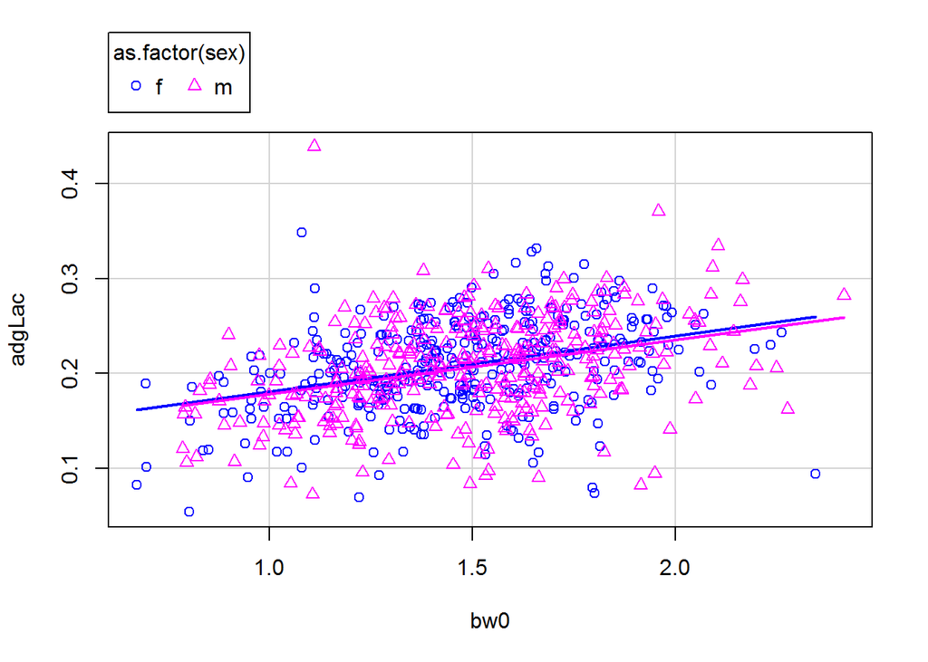

```r
scatterplot(adgLac~bw0|as.factor(sex),smooth=F,data=dadesFr) # F=M
```

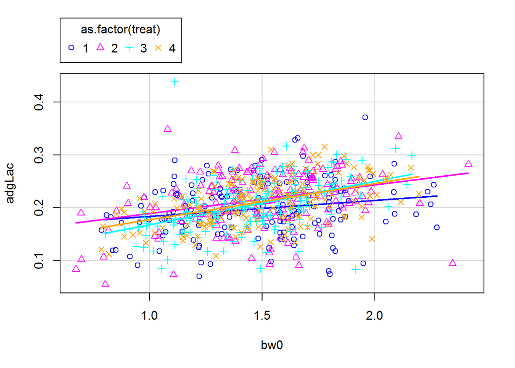

```r
scatterplot(adgLac~bw0|as.factor(treat),smooth=F,data=dadesFr) # dif?
```

### De totes les explicatives en bw163

Variables o factors explicatius: bw0, adgLac, sex, treat, band, block (descartat perquè ja hi posem bw0 i adg07, els blocs tant a 0 com a 20 dies són redundants)

*De bw0 en bw163, en funció dels grups definits pels factors*

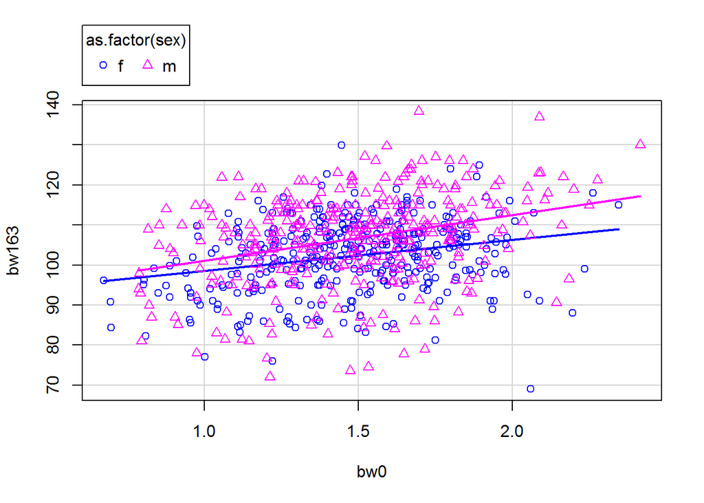

```r
require(car)
# interacció i intercept diferents
scatterplot(bw163~bw0|as.factor(sex),smooth=F,data=dadesFr)
```

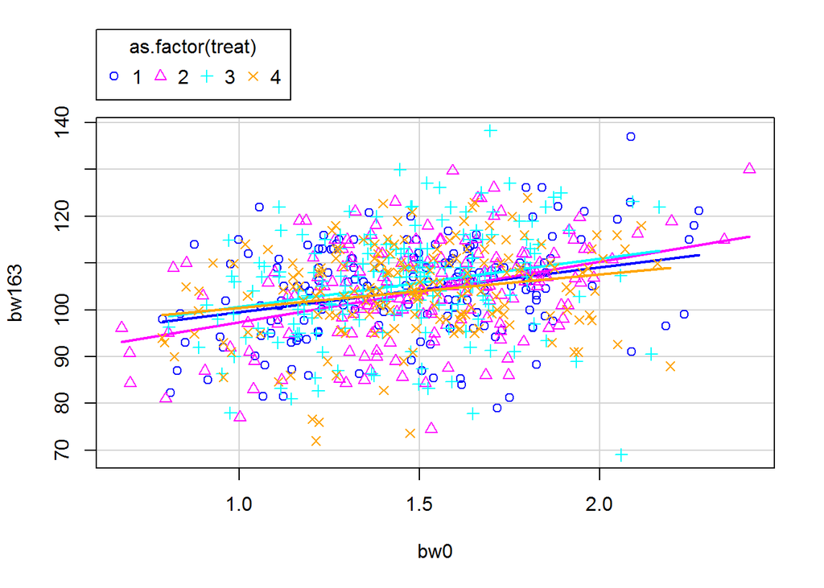

```r
scatterplot(bw163~bw0|as.factor(treat),smooth=F,data=dadesFr)
```

*De adgLac en bw163, en funció dels grups definits pels factors*

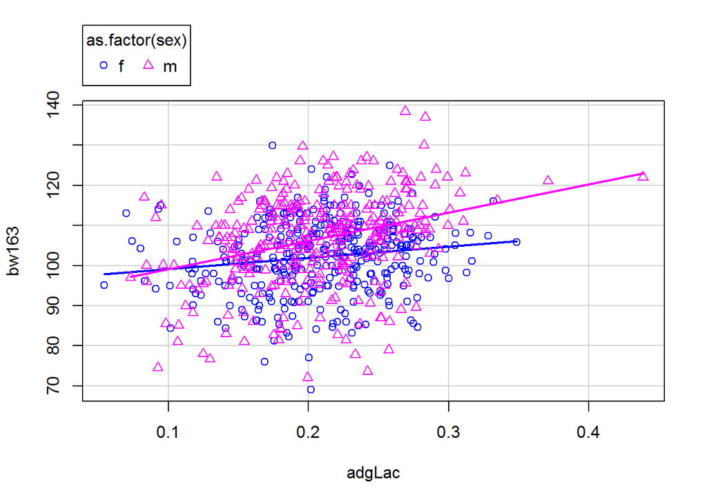

```r
scatterplot(bw163~adgLac|as.factor(sex),smooth=F,data=dadesFr)
```

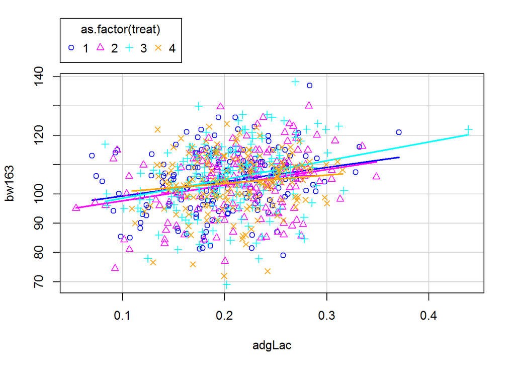

```r
scatterplot(bw163~adgLac|as.factor(treat),smooth=F,data=dadesFr)
```

Considerem el tractament 4 separat dels altres (mneys pendent), però sembla degut a unes poques dades que donen més pendent als altres tractaments.

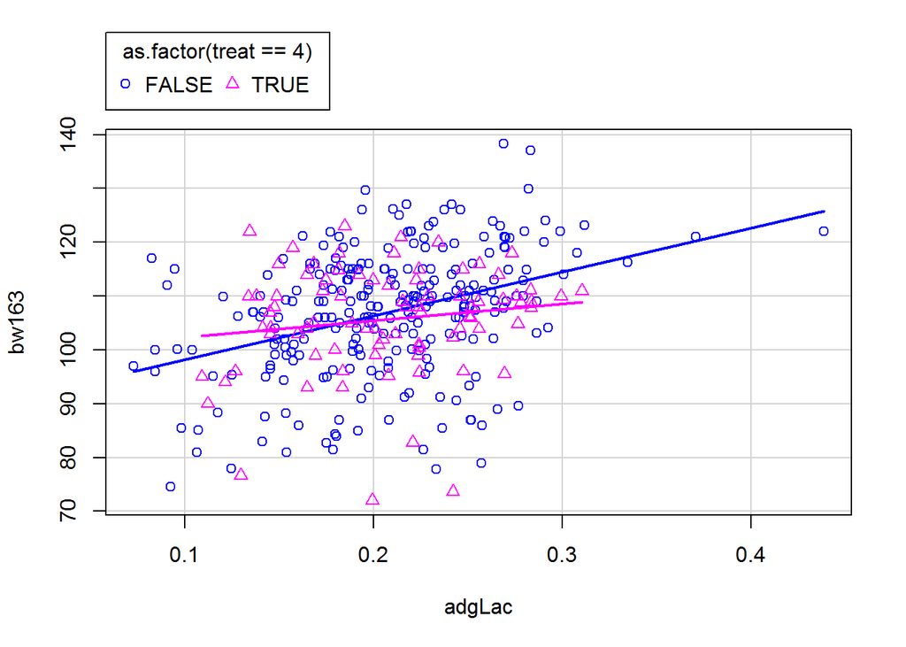

```r
scatterplot(bw163~adgLac|as.factor(treat==4),smooth=F,data=dadesFrM) # dif?
```

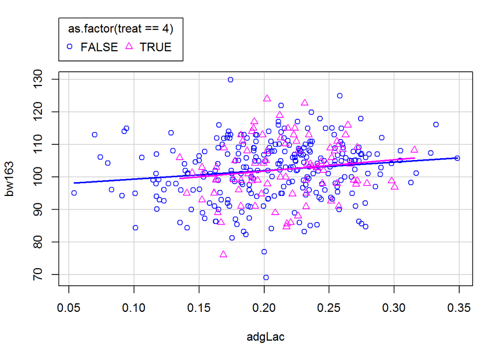

```r
scatterplot(bw163~adgLac|as.factor(treat==4),smooth=F,data=dadesFrF) # no dif
```

L’efecte bloc de pes, com ja he dit abans, no sembla pertinent en aquest nivell perquè ja usem la variable pes al neixment (no té sentit fer blocs de pes de la mateixa variable que s’hi posa, i tampoc tenen gaire sentit els blocs al deslletament peruè hi posem el creixement mitjà diari …)

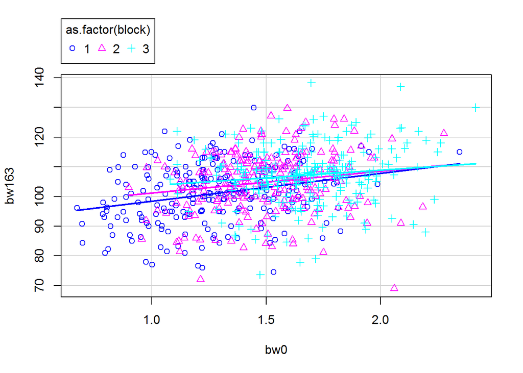

```r
scatterplot(bw163~bw0|as.factor(block),smooth=F,data=dadesFr)
```

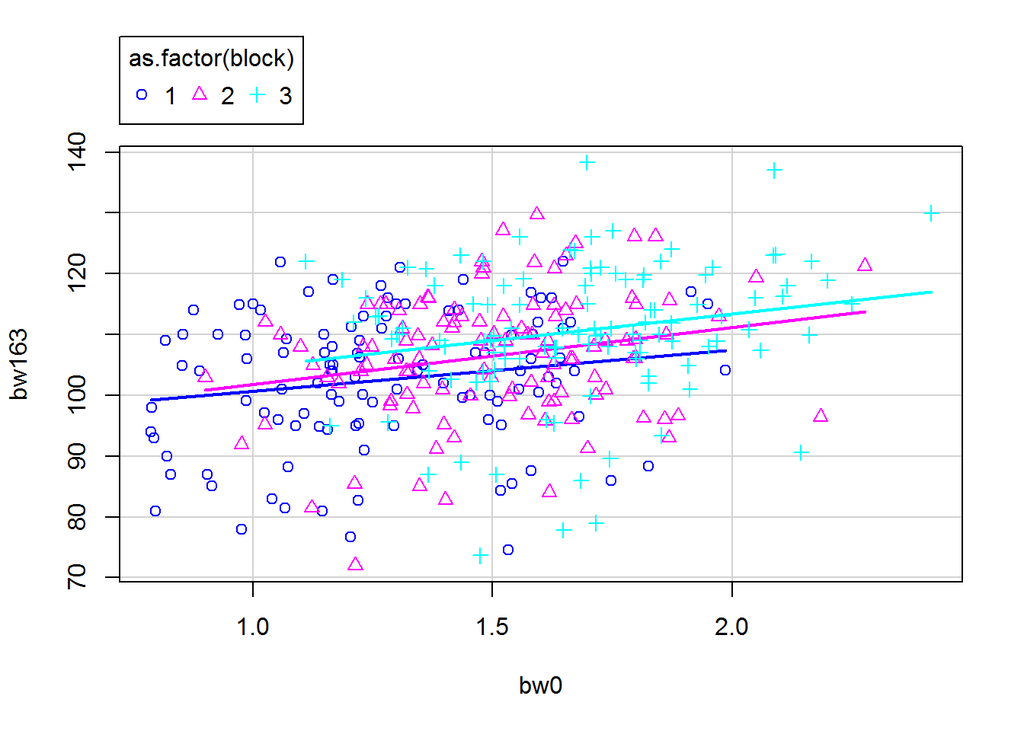

```r
scatterplot(bw163~bw0|as.factor(block),smooth=F,data=dadesFrM)
```

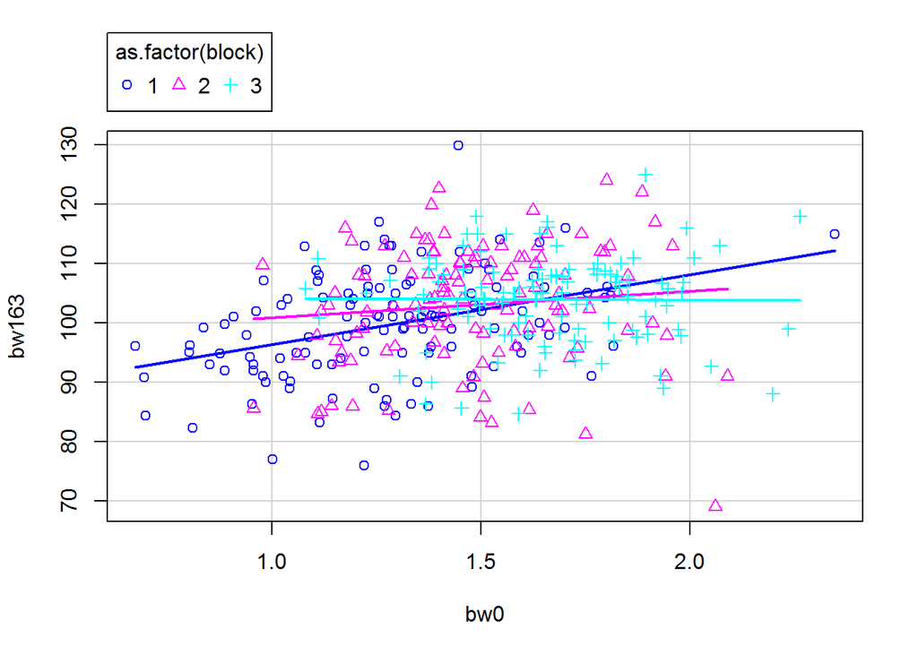

```r
scatterplot(bw163~bw0|as.factor(block),smooth=F,data=dadesFrF)
```

```r
# interacció?
# curiosament, sembla que les femelles més petites creixen més
# sembla l'efecte dún úni animal ??
## cal estudiar aquest cas ??
```

((El que ve a continuació no ho he revisat … ja em direu si hi ha alguna cosa rellevant))

```r
subset(dadesFrF,bw0>2)
```

```
## # A tibble: 9 x 13
##     sow treat  band   pig sex   block   bw0  bw20  bw33  bw60 bw120 bw163 adgLac
##   <dbl> <dbl> <dbl> <dbl> <chr> <fct> <dbl> <dbl> <dbl> <dbl> <dbl> <dbl>  <dbl>
## 1  7403     4     3  1371 f     3      2.01  6.50  8.39  20.2  68.8 111.  0.225
## 2  7403     4     3  1389 f     3      2.05  7.08  8.87  20.9  65.7  92.6 0.251
## 3  9040     3     3  1105 f     2      2.06  6.09  8.99  17.9  44    69   0.202
## 4  7097     4     3  1690 f     3      2.07  7.32  9.96  20.3  73   113   0.263
## 5  8113     1     3  1164 f     2      2.09  5.85  7.13  17.1  67    91   0.188
## 6  8298     4     3  1101 f     3      2.20  6.72  8.16  18.5  57    88   0.226
## 7  8113     1     3  1152 f     3      2.24  6.84  8.26  17.5  61    99   0.230
## 8  8113     1     3  1150 f     3      2.26  7.12  7.91  18    77   118   0.243
## 9  7387     2     1   722 f     1      2.35  4.23 10.2   22.8  76   115   0.0943
```

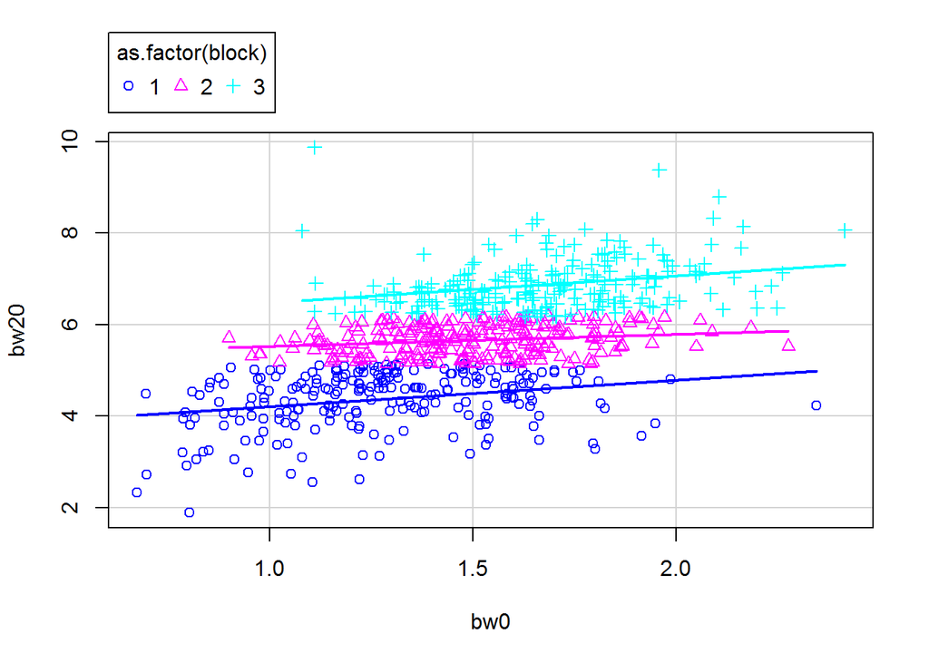

```r
## es la femella que pesa més, pig=722, que després a d20 és molt petita
scatterplot(bw20~bw0|as.factor(block),smooth=F,data=dadesFr)
```

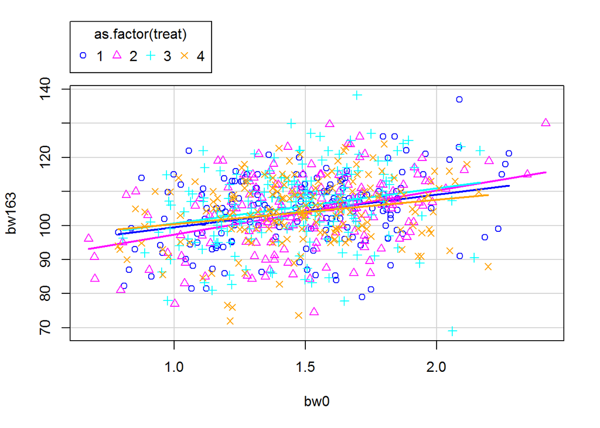

```r
scatterplot(bw163~bw0|as.factor(treat),smooth=F,data=dadesFr)
```

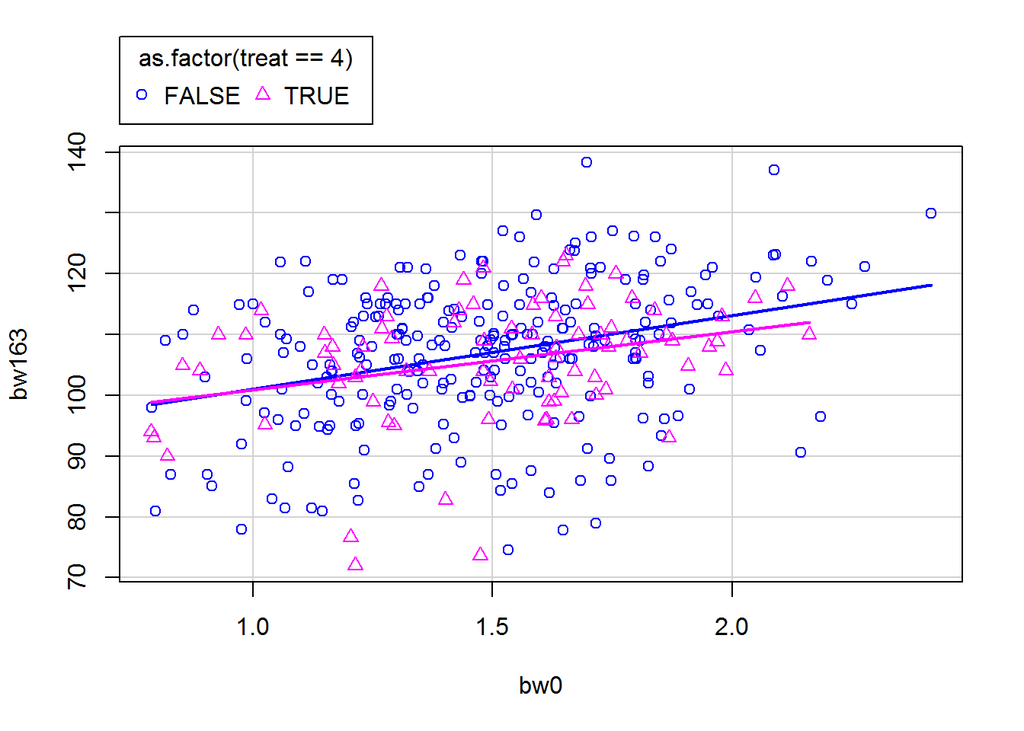

```r
scatterplot(bw163~bw0|as.factor(treat==4),smooth=F,data=dadesFrM)
```

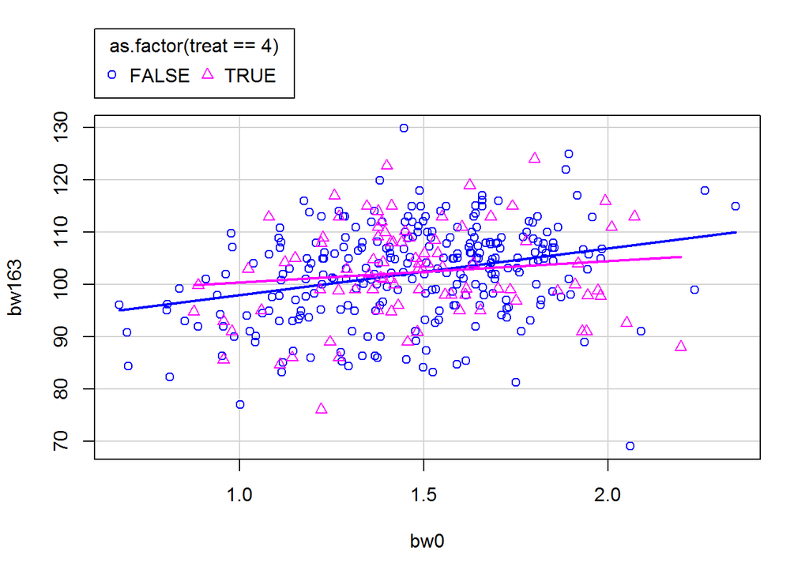

```r
scatterplot(bw163~bw0|as.factor(treat==4),smooth=F,data=dadesFrF)
```

## Models

```r
mod00<-lm(bw163~bw0+adgLac+as.factor(treat)+as.factor(band)+as.factor(sex)
          ,data=dadesFr,x=T)
summary(mod00)
```

```
##
## Call:
## lm(formula = bw163 ~ bw0 + adgLac + as.factor(treat) + as.factor(band) +
##     as.factor(sex), data = dadesFr, x = T)
##
## Residuals:
##     Min      1Q  Median      3Q     Max
## -38.069  -5.758   0.510   6.453  28.782
##
## Coefficients:
##                   Estimate Std. Error t value Pr(>|t|)
## (Intercept)        83.7696     2.1576  38.825  < 2e-16 ***
## bw0                 7.9785     1.2910   6.180 1.10e-09 ***
## adgLac             35.5636     7.8425   4.535 6.81e-06 ***
## as.factor(treat)2  -1.0100     1.0685  -0.945   0.3449
## as.factor(treat)3   0.9922     1.0358   0.958   0.3384
## as.factor(treat)4  -0.6521     1.0614  -0.614   0.5392
## as.factor(band)3   -1.2983     0.7434  -1.746   0.0812 .
## as.factor(sex)m     4.3918     0.7364   5.964 3.95e-09 ***
## ---
## Signif. codes:  0 '***' 0.001 '**' 0.01 '*' 0.05 '.' 0.1 ' ' 1
##
## Residual standard error: 9.649 on 686 degrees of freedom
## Multiple R-squared:  0.1558, Adjusted R-squared:  0.1472
## F-statistic: 18.08 on 7 and 686 DF,  p-value: < 2.2e-16
```

```r
# trec treat i band i comprovo que no aporten significacio
mod02<-lm(bw163~bw0+adgLac+as.factor(sex),data=dadesFr,x=T)
summary(mod02)   # bon model
```

```
##
## Call:
## lm(formula = bw163 ~ bw0 + adgLac + as.factor(sex), data = dadesFr,
##     x = T)
##
## Residuals:
##     Min      1Q  Median      3Q     Max
## -37.523  -5.454   0.591   6.725  29.115
##
## Coefficients:
##                 Estimate Std. Error t value Pr(>|t|)
## (Intercept)      83.8856     2.0835  40.261  < 2e-16 ***
## bw0               7.7371     1.2894   6.000 3.18e-09 ***
## adgLac           33.2290     7.7689   4.277 2.16e-05 ***
## as.factor(sex)m   4.3398     0.7353   5.902 5.64e-09 ***
## ---
## Signif. codes:  0 '***' 0.001 '**' 0.01 '*' 0.05 '.' 0.1 ' ' 1
##
## Residual standard error: 9.675 on 690 degrees of freedom
## Multiple R-squared:  0.1464, Adjusted R-squared:  0.1427
## F-statistic: 39.44 on 3 and 690 DF,  p-value: < 2.2e-16
```

```r
anova(mod02,mod00)
```

```
## Analysis of Variance Table
##
## Model 1: bw163 ~ bw0 + adgLac + as.factor(sex)
## Model 2: bw163 ~ bw0 + adgLac + as.factor(treat) + as.factor(band) + as.factor(sex)
##   Res.Df   RSS Df Sum of Sq      F Pr(>F)
## 1    690 64581
## 2    686 63870  4    711.04 1.9092 0.1071
```

```r
# afegeixo interaccions: no significatiu
mod03<-lm(bw163~bw0*as.factor(sex)+adgLac,data=dadesFr,x=T)
summary(mod03)
```

```
##
## Call:
## lm(formula = bw163 ~ bw0 * as.factor(sex) + adgLac, data = dadesFr,
##     x = T)
##
## Residuals:
##     Min      1Q  Median      3Q     Max
## -36.408  -5.578   0.757   6.618  29.071
##
## Coefficients:
##                     Estimate Std. Error t value Pr(>|t|)
## (Intercept)           86.654      2.766  31.327  < 2e-16 ***
## bw0                    5.846      1.791   3.263  0.00115 **
## as.factor(sex)m       -1.092      3.649  -0.299  0.76477
## adgLac                33.292      7.762   4.289 2.05e-05 ***
## bw0:as.factor(sex)m    3.672      2.416   1.520  0.12901
## ---
## Signif. codes:  0 '***' 0.001 '**' 0.01 '*' 0.05 '.' 0.1 ' ' 1
##
## Residual standard error: 9.665 on 689 degrees of freedom
## Multiple R-squared:  0.1492, Adjusted R-squared:  0.1443
## F-statistic: 30.22 on 4 and 689 DF,  p-value: < 2.2e-16
```

```r
anova(mod03,mod02)
```

```
## Analysis of Variance Table
##
## Model 1: bw163 ~ bw0 * as.factor(sex) + adgLac
## Model 2: bw163 ~ bw0 + adgLac + as.factor(sex)
##   Res.Df   RSS Df Sum of Sq      F Pr(>F)
## 1    689 64365
## 2    690 64581 -1   -215.79 2.3099  0.129
```

```r
# afegeixo tractament només mascles
mod02m<-lm(bw163~bw0+adgLac*as.factor(treat==4),data=dadesFrM,x=T)
summary(mod02m)  # provat band però no afegeix res
```

```
##
## Call:
## lm(formula = bw163 ~ bw0 + adgLac * as.factor(treat == 4), data = dadesFrM,
##     x = T)
##
## Residuals:
##     Min      1Q  Median      3Q     Max
## -33.296  -5.291   0.880   7.384  25.451
##
## Coefficients:
##                                  Estimate Std. Error t value Pr(>|t|)
## (Intercept)                        79.998      3.429  23.330  < 2e-16 ***
## bw0                                 8.982      1.943   4.623 5.41e-06 ***
## adgLac                             65.652     12.850   5.109 5.46e-07 ***
## as.factor(treat == 4)TRUE          11.974      5.670   2.112   0.0355 *
## adgLac:as.factor(treat == 4)TRUE  -64.654     26.809  -2.412   0.0164 *
## ---
## Signif. codes:  0 '***' 0.001 '**' 0.01 '*' 0.05 '.' 0.1 ' ' 1
##
## Residual standard error: 10.39 on 334 degrees of freedom
## Multiple R-squared:  0.1674, Adjusted R-squared:  0.1574
## F-statistic: 16.79 on 4 and 334 DF,  p-value: 1.498e-12
```

```r
# afegeixo tractament només femelles: nosignificatiu
mod02f<-lm(bw163~bw0+adgLac*as.factor(treat),data=dadesFrF,x=T)
summary(mod02f)
```

```
##
## Call:
## lm(formula = bw163 ~ bw0 + adgLac * as.factor(treat), data = dadesFrF,
##     x = T)
##
## Residuals:
##     Min      1Q  Median      3Q     Max
## -38.115  -5.530   0.833   5.670  27.454
##
## Coefficients:
##                          Estimate Std. Error t value Pr(>|t|)
## (Intercept)                85.780      4.154  20.647  < 2e-16 ***
## bw0                         7.378      1.710   4.316 2.08e-05 ***
## adgLac                     26.742     17.358   1.541    0.124
## as.factor(treat)2           3.266      5.244   0.623    0.534
## as.factor(treat)3           5.680      5.625   1.010    0.313
## as.factor(treat)4           3.150      6.338   0.497    0.620
## adgLac:as.factor(treat)2  -18.571     24.240  -0.766    0.444
## adgLac:as.factor(treat)3  -24.480     27.264  -0.898    0.370
## adgLac:as.factor(treat)4  -14.978     29.499  -0.508    0.612
## ---
## Signif. codes:  0 '***' 0.001 '**' 0.01 '*' 0.05 '.' 0.1 ' ' 1
##
## Residual standard error: 8.796 on 346 degrees of freedom
## Multiple R-squared:  0.07499,    Adjusted R-squared:  0.0536
## F-statistic: 3.506 on 8 and 346 DF,  p-value: 0.0006527
```

```r
## per femelles ens quedem amb el model sense tractament
mod02f<-lm(bw163~ bw0,data=dadesFrF,x=T)
summary(mod02f)  # coincideix amb el pendent i intercept de femelles de mod03
```

```
##
## Call:
## lm(formula = bw163 ~ bw0, data = dadesFrF, x = T)
##
## Residuals:
##     Min      1Q  Median      3Q     Max
## -37.786  -5.553   0.644   5.872  27.980
##
## Coefficients:
##             Estimate Std. Error t value Pr(>|t|)
## (Intercept)   90.718      2.354  38.544  < 2e-16 ***
## bw0            7.800      1.569   4.971 1.04e-06 ***
## ---
## Signif. codes:  0 '***' 0.001 '**' 0.01 '*' 0.05 '.' 0.1 ' ' 1
##
## Residual standard error: 8.754 on 353 degrees of freedom
## Multiple R-squared:  0.06543,    Adjusted R-squared:  0.06279
## F-statistic: 24.72 on 1 and 353 DF,  p-value: 1.039e-06
```

```r
mod03f<-lm(bw163~ bw0+as.factor(band),data=dadesFrF,x=T)
summary(mod03f)   # en femelles sí !!
```

```
##
## Call:
## lm(formula = bw163 ~ bw0 + as.factor(band), data = dadesFrF,
##     x = T)
##
## Residuals:
##     Min      1Q  Median      3Q     Max
## -36.895  -5.629   0.337   5.770  29.096
##
## Coefficients:
##                  Estimate Std. Error t value Pr(>|t|)
## (Intercept)        91.027      2.347  38.779  < 2e-16 ***
## bw0                 8.166      1.571   5.197 3.44e-07 ***
## as.factor(band)3   -1.954      0.939  -2.082   0.0381 *
## ---
## Signif. codes:  0 '***' 0.001 '**' 0.01 '*' 0.05 '.' 0.1 ' ' 1
##
## Residual standard error: 8.713 on 352 degrees of freedom
## Multiple R-squared:  0.0768, Adjusted R-squared:  0.07155
## F-statistic: 14.64 on 2 and 352 DF,  p-value: 7.801e-07
```

**La conclusió és que sembla recomanable no distingir mascles de femelles i considerar models que tinguin bw00, adgLac i sex.

## Causal inference

### general

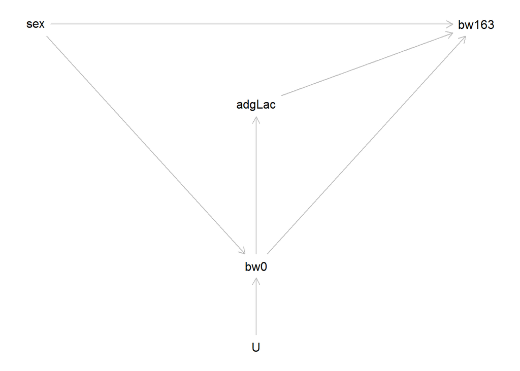

```r
require(dagitty)
require(lavaan)

gbw163 <- dagitty('dag{
U -> bw0  -> bw163
sex  -> bw0
sex  -> bw163
bw0  -> adgLac -> bw163
 }')
#U -> bw163  # no permet estimar l'efecte de bw0

coordinates(gbw163) <- list(
  x=c(sex=1,U=2,bw0=2, adgLac =2,bw163=3),
  y=c(sex=1,U=3,bw0=2.5, adgLac =1.5,bw163=1))
plot(gbw163,main="Causal graph")
```

```r
# adjustment graphs
adjustmentSets(gbw163, "bw0", "bw163")  # sex
```

```
##  { sex }
```

```r
adjustmentSets(gbw163, "adgLac", "bw163") # bw00
```

```
##  { bw0 }
```

```r
adjustmentSets(gbw163, "sex", "bw163") # res
```

```
##  {}
```

```r
# models que ens indica la inferència causal
## amb estimació dels efectes
## fem <- dadesFr$sex=="f"
## dadesFr$fem<-fem
## bw0Xfem <- dadesFr$bw0*dadesFr$fem
mod.efBw0 <- lm(bw163~bw0+as.factor(sex),data=dadesFr,x=T,y=T)
sum.efBw0 <- summary(mod.efBw0) # 9.866:  per 100g --> 1kg
ci.beta1(mod=mod.efBw0,vexpl=1,nsd=1)
```

```
## $coef
## [1] 9.658961
##
## $linf.coef
## [1] 7.256466
##
## $lsup.coef
## [1] 12.06146
##
## $linf.Incy
## [1] 2.207466
##
## $lsup.Incy
## [1] 3.669176
```

```r
mod.efAdgLac <- lm(bw163~bw0+adgLac,data=dadesFr,x=T,y=T)
sum.efAdgLac <- summary(mod.efAdgLac)
ci.beta1(mod=mod.efAdgLac,vexpl=2,nsd=1)
```

```
## $coef
## [1] 31.82715
##
## $linf.coef
## [1] 16.21194
##
## $lsup.coef
## [1] 47.44236
##
## $linf.Incy
## [1] 0.8183159
##
## $lsup.Incy
## [1] 2.394706
```

```r
mod.efBand<- lm(bw163~as.factor(sex),data=dadesFr,x=T,y=T)
sum.efBand<- summary(mod.efBand)
ci.beta1(mod=mod.efBand,vexpl=1,nsd=1)  ## sd de sex, com s'interpreta??
```

```
## $coef
## [1] 4.418266
##
## $linf.coef
## [1] 2.894549
##
## $lsup.coef
## [1] 5.941983
##
## $linf.Incy
## [1] 1.447934
##
## $lsup.Incy
## [1] 2.972344
```

```r
# model total: no per explicar els efectes
# per veure la quantitat de variabilitat explicada

mod <- lm(bw163~bw0+adgLac+as.factor(sex),data=dadesFr,x=T,y=T)
smod <- summary(mod)

# 14.67 de R2: la resta és variabilitat individual, no afecta la mitjana
```

### Sexe = F (crec que no cal)

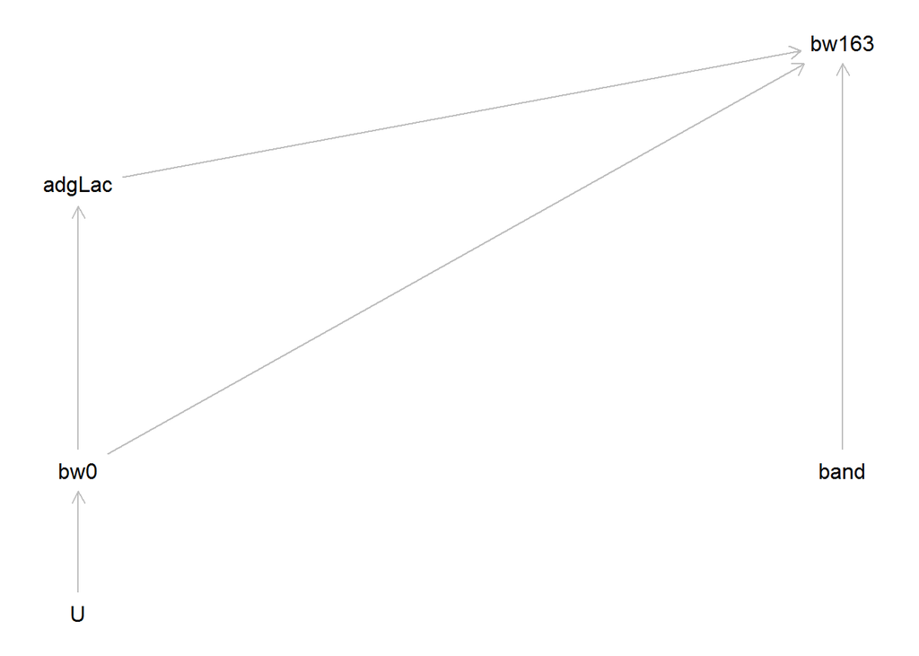

```r
gbw163F <- dagitty('dag{
U -> bw0  -> bw163
bw0  -> adgLac -> bw163
band -> bw163
 }')
#U -> bw163  # no permet estimar l'efecte de bw0

coordinates(gbw163F) <- list(
  x=c(U=2,bw0=2, adgLac =2,band=3,bw163=3),
  y=c(U=3,bw0=2.5, adgLac =1.5,band=2.5,bw163=1))
plot(gbw163F,main="Causal graph")
```

```r
# adjustment graphs
adjustmentSets(gbw163F, "bw0", "bw163")     # res
```

```
##  {}
```

```r
adjustmentSets(gbw163F, "adgLac", "bw163")  # bw00 !
```

```
##  { bw0 }
```

```r
adjustmentSets(gbw163F, "band", "bw163")    # res
```

```
##  {}
```

```r
# models
modF.efBw0 <- lm(bw163~bw0, data=dadesFrF,x=T)
sumF.efBw0 <- summary(modF.efBw0) # 7.8:  per 100g --> 0.780kg
ci.beta1(mod=modF.efBw0,vexpl=1,nsd=1)
```

```
## $coef
## [1] 7.799722
##
## $linf.coef
## [1] 4.714168
##
## $lsup.coef
## [1] 10.88528
##
## $linf.Incy
## [1] 1.397966
##
## $lsup.Incy
## [1] 3.227981
```

```r
modF.efAdgLac <- lm(bw163~bw0+adgLac, data=dadesFrF,x=T)
sumF.efAdgLac <- summary(modF.efAdgLac) # 7.8:  per 100g --> 0.780kg
ci.beta1(mod=modF.efAdgLac,vexpl=1,nsd=1)
```

```
## $coef
## [1] 7.048636
##
## $linf.coef
## [1] 3.755424
##
## $lsup.coef
## [1] 10.34185
##
## $linf.Incy
## [1] 1.113654
##
## $lsup.Incy
## [1] 3.06683
```

```r
modF.efBand<- lm(bw163~as.factor(band), data=dadesFrF,x=T)
sumF.efBand<- summary(modF.efBand) # 7.8:  per 100g --> 0.780kg
ci.beta1(mod=modF.efBand,vexpl=1,nsd=1)
```

```
## $coef
## [1] -1.407781
##
## $linf.coef
## [1] -3.309196
##
## $lsup.coef
## [1] 0.493633
##
## $linf.Incy
## [1] -1.642348
##
## $lsup.Incy
## [1] 0.2449891
```

### Sexe = M (crec que no cal)

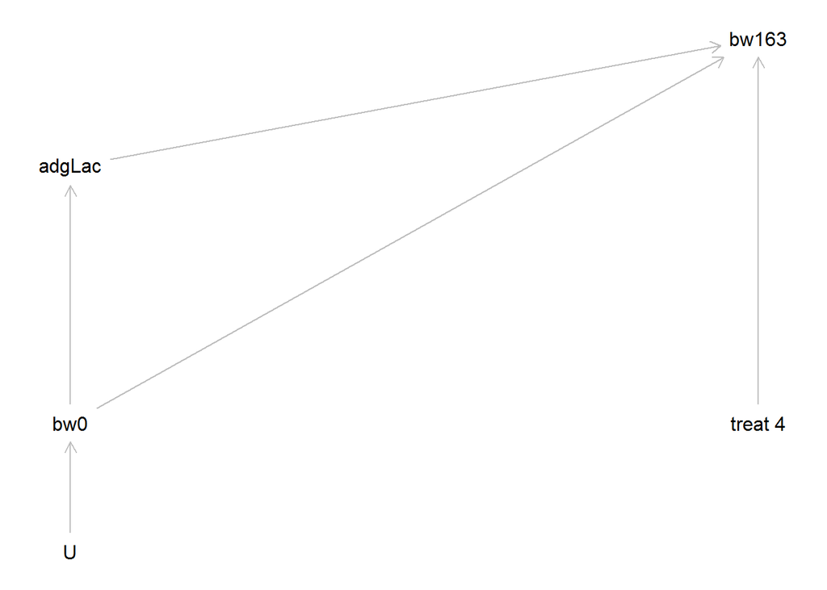

```r
gbw163F <- dagitty('dag{
U -> bw0  -> bw163
bw0  -> adgLac -> bw163
"treat 4" -> bw163
 }')
#U -> bw163  # no permet estimar l'efecte de bw0

coordinates(gbw163F) <- list(
  x=c(U=2,bw0=2, adgLac =2,"treat 4"=3,bw163=3),
  y=c(U=3,bw0=2.5, adgLac =1.5,"treat 4"=2.5,bw163=1))
plot(gbw163F,main="Causal graph")
```

```r
# adjustment graphs
adjustmentSets(gbw163F, "bw0", "bw163")     # res
```

```
##  {}
```

```r
adjustmentSets(gbw163F, "adgLac", "bw163")  # bw00 !
```

```
##  { bw0 }
```

```r
adjustmentSets(gbw163F, "treat 4", "bw163")    # res
```

```
##  {}
```

```r
# models
modM.efBw0 <- lm(bw163~bw0, data=dadesFrM,x=T)
sumM.efBw0 <- summary(modM.efBw0) # 7.8:  per 100g --> 0.780kg
ci.beta1(mod=modM.efBw0,vexpl=1,nsd=1)
```

```
## $coef
## [1] 11.41584
##
## $linf.coef
## [1] 7.727464
##
## $lsup.coef
## [1] 15.10422
##
## $linf.Incy
## [1] 2.412506
##
## $lsup.Incy
## [1] 4.715521
```

```r
modM.efAdgLac <- lm(bw163~bw0+adgLac, data=dadesFrM,x=T)
sumM.efAdgLac <- summary(modM.efAdgLac) # 7.8:  per 100g --> 0.780kg
ci.beta1(mod=modM.efAdgLac,vexpl=1,nsd=1)
```

```
## $coef
## [1] 8.393961
##
## $linf.coef
## [1] 4.571359
##
## $lsup.coef
## [1] 12.21656
##
## $linf.Incy
## [1] 1.427173
##
## $lsup.Incy
## [1] 3.813998
```

```r
modM.efTreat<- lm(bw163~as.factor(treat==4), data=dadesFrM,x=T)
sumM.efTreat<- summary(modM.efTreat) # 7.8:  per 100g --> 0.780kg
ci.beta1(mod=modM.efTreat,vexpl=1,nsd=1)
```

```
## $coef
## [1] -1.273269
##
## $linf.coef
## [1] -4.087208
##
## $lsup.coef
## [1] 1.54067
##
## $linf.Incy
## [1] -1.76006
##
## $lsup.Incy
## [1] 0.6634536
```